# Jack Hu

## About me

Hi! I'm a 4th year UBC student studying business and computer science, and currently working as an assistant in the Office of Pediatric Surgical Evaluation and Innovation at BC Children's Hospital Research Institute. My strengths lie at the intersection of data analysis and business thinking, and I'm passionate about using technology to create value. I am open-minded, reflective, and eager to learn!

[Resume](https://jhu12.github.io/jack_hu_resume.pdf)

[LinkedIn](https://www.linkedin.com/in/jack-hu-ubc/)

jackhu512@gmail.com

## Research Work

Since May 2021, I have been working as an undergraduate research assistant to professor Arslan Aziz at UBC Sauder School of Business. Below are a few samples of my work. I have been using R to create visualizations which help to clearly and effectively communicate findings from the experiment data.

### Rating Inflation

When using online platforms such as food delivery services, buyers can rate their experiences with each seller, usually on a 5-star scale. Rating inflation is the phenomenon where the average rating on a platform is unrealistically high, and there is little variance across sellers, making their informativeness very limited. A research paper that I worked on studied the effect of this occurrence on users’ behaviors, such as purchase frequency and tendency to try new sellers or repeatedly buy from familiar ones. Below is a plot I created from a data set of 3,000,000+ observations. It shows that rating inflation caused a decrease in user trials.

#### Proportion of Users, Trials

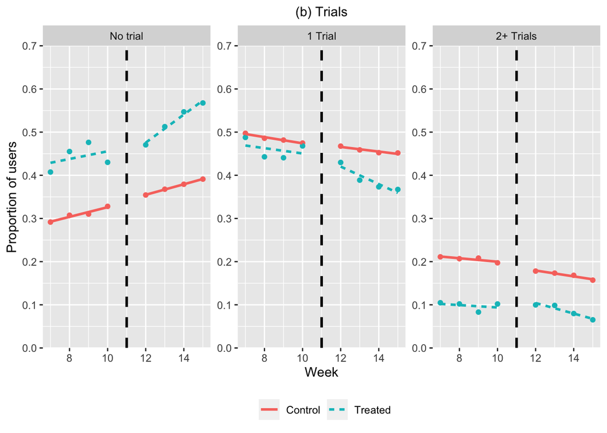

In this experiment, both the control group and the treated group were exposed to artificially deflated ratings for 10 weeks. Then in week 11, the rating deflation was removed for the treated group and kept for the control group. The occurrence of rating inflation showed an increase in the proportion of users who make no trials each week, and a decrease in the proportion of users who make some trial(s). The conclusion is that users are less likely to try new restaurants due to rating inflation.

See the links below for a couple more samples of the work (with code) that I have done for this paper.

[User Activity Levels](https://jhu12.github.io/samples/fig4.html)

[Synthetic Control Analysis](https://jhu12.github.io/samples/synth_control_region.html)

### Privacy and Tracking of Online User Behaviour

Another fascinating paper I worked on was about finding a way to balance the trade-off between tracking users’ online behavior to serve them with relevant content and raising privacy concerns. The experiment identified a few variables and their predictive values and privacy costs. The predictive value is how useful the variable is to inform data collectors and advertisers, and the privacy cost is the user’s perception of how invasive the variable is to their privacy.

#### Predictive Value vs. Privacy Cost

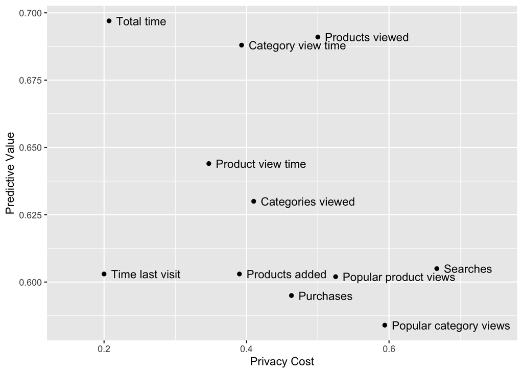

#### Variable description

| Variable | Description |
| --- | --- |
| Searches | How many times searched for a product on the website using the search function |
| Popular category views | How many times viewed most-viewed product category page |
| Popular product views | How many times viewed most-viewed product page |
| Products viewed | How many products viewed on the website |
| Purchases | How many purchases made on the website |
| Categories viewed | How many product category pages viewed on the website |
| Category view time | How much time spent viewing product category pages |
| Products added | How many products added to your shopping cart |
| Product view time | How much time spent viewing product pages |
| Total time | The total time spent on the website |
| Time last visit | Time since last visit to the website |